# Project 2C

Question: Are the hemagluttin from the two H3N2 strain in 2016 more similar to that of the 1968 H3N2 pandemic or the strain found in 2004?

Hypothesis: If the hemagluttins of different H3N2 human infecting strains are compared to each other, then the 2016 strain will have a higher protein sequence similarity to the 2004 and 2005 strains, which would support the pattern of the H3N2 strains decreased virus avidity?

Background: Influenza A viruses or IAV have been a major concern to the world as they have been the cause of 3 major pandemics in the past. These pandemics were the 1918 Spanish Influenza caused by H1N1, the 1957 Asian Influenza caused by H2N2, and the 1968 Hong Kong influenza caused by H3N2 (Hiroshi). Influenza A viruses are further subtyped based on two of their surface glycoproteins. These proteins are the hemagluttin or HA and neuraminidase or NA. The NA protein in IAV are responsible for cleaving sialic acid on the surface of the host cell, which allows for the viruses to leave the host cell and further spread to other cells. There are currently 11 known NA’s. The HA protein is important for the virus to be able to bind to sialic acid on the host cell, so it allows the virus into the cell. There are currently 18 known HA proteins. H3N2 is a subtype of influenza a that emerged in 1968 for the first time in humans in Hong Kong and was the cause of a global pandemic associated with more than one million deaths (Allen). From then on, H3N2 has been closely studied as it continues to circulate and evolve within the human population. However, a recent study found that from 2001 to 2010 there has been a pattern of declined avidity of human H3 viruses for avian receptors and also a significant decrease in H3’s affinity towards human for human receptors (Pu et al). The question is this pattern in H3N2 evolution still continuing even in more recent years.

Packages: BiocManager is useful for statistical analysis and comprehending highthoroughput genomic data. In my code specifically it was useful in running the multiple sequence alignment for my amino acid sequences.

msa: is a package within Biocmanager that provides the algorithm for running multiple sequence alignments

seqinr: is a package that is necessary for data analysis and visualization of biological sequences, like data and proteins. In the code this was specifically used to find the distance between each multiple sequence alignment.

ape is a package that allows for the reading, writing, plotting and manipulation of phylogenetic tree, so it was used to plot a phylogenetic tree of my amino acid sequences.

bio3d is a package that contains algorithms to analyze a proteins structure and sequence. It also allows for the ability to statistically and graphically work with biological sequence and structural data, like plotting principal component analysis and assessing the distance matrix.

readr is a package that allows the user to quickly and easily read in many data file types, like pdb, fasta and etc.

```r
#1st Bioinformatic Method: Multiple Sequence Alignment and Phylogenetic Tree (visualization)
#packages
library(BiocManager)
library(msa)
library(seqinr)
library(ape)

#read in amino acid sequence files, which were found on NCBI under the names
#have to read in fasta files as a string, instead of vector in order for the function msa to work
H3N2_1968_hongkong<- readAAStringSet("H3N2:1968.fasta")
H3N2_2004_sweden<-readAAStringSet("H3N2:2004.fasta")
H3N2_2016_tenessee<- readAAStringSet("H3N2:2016:tenessee.fasta")
H3N2_2016_florida<-readAAStringSet("H3N2:2016:florida.fasta")

#use multiple sequence alignment on 4 variables
all<-c(H3N2_2004_sweden, H3N2_1968_hongkong, H3N2_2016_florida, H3N2_2016_tenessee)
H3N2_alignment<-msa(all, "ClustalW")
```

```
use default substitution matrix
```

```r
print(H3N2_alignment, show="complete")
```

```
MsaAAMultipleAlignment with 4 rows and 566 columns
    aln (1..53)                                           names
[1] MKTIIALSYILCLVFAQKIPGNDNSTATLCLGHHAVPNGTIVKTITNDRIEVT APO18550.1 hemagg...
[2] MKTIIALSYILCLVFAQKIPGNDNSTATLCLGHHAVPNGTIVKTITNDRIEVT APO18562.1 hemagg...
[3] ----------------QKLPGNDNSTATLCLGHHAVPNGTIVKTITNDQIEVT pdb|2YP5|A Chain ...
[4] MKTIIALSYIFCLALGQDLPGNDNSTATLCLGHHAVPNGTLVKTITDDQIEVT sp|Q91MA7.1|HEMA_...
Con MKTIIALSYILCLVFAQK?PGNDNSTATLCLGHHAVPNGTIVKTITND?IEVT Consensus

    aln (54..106)                                         names
[1] NATELVQNSSIGEICDSPHQVLDGENCTLIDALLGDPQCDGFQNKKWDLFVER APO18550.1 hemagg...
[2] NATELVQNSSIGEICDSPHQILDGENCTLIDALLGDPQCDGFQNKKWDLFVER APO18562.1 hemagg...
[3] NATELVQSSSTGGICDSPHQILDGENCTLIDALLGDPQCDGFQNKKWDLFVER pdb|2YP5|A Chain ...
[4] NATELVQSSSTGKICNNPHRILDGIDCTLIDALLGDPHCDVFQNETWDLFVER sp|Q91MA7.1|HEMA_...
Con NATELVQ?SS?GEICDSPHQILDGENCTLIDALLGDPQCDGFQNKKWDLFVER Consensus

    aln (107..159)                                        names
[1] SRAYSNCYPYDVPDYASLRSLVASSGTLEFKNESFNWTGVTQNGTSSACIRRS APO18550.1 hemagg...
[2] SKAYSNCYPYDVPDYASLRSLVASSGTLEFNNESFNWTGVTQNGTSSACIRRS APO18562.1 hemagg...
[3] SKAYSNCYPYDVPDYASLRSLVASSGTLEFNNESFNWTGVTQNGTSSACKRRS pdb|2YP5|A Chain ...
[4] SKAFSNCYPYDVPDYASLRSLVASSGTLEFITEGFTWTGVTQNGGSNACKRGP sp|Q91MA7.1|HEMA_...
Con SKAYSNCYPYDVPDYASLRSLVASSGTLEFNNESFNWTGVTQNGTSSAC?RRS Consensus

    aln (160..212)                                        names
[1] SSSFFSRLNWLTHLNYTYPALNVTMPNKEQFDKLYIWGVHHPGTDKDQIFLYA APO18550.1 hemagg...
[2] SSSFFSRLNWLTHLNYTYPALNVTMPNKEQFDKLYIWGVHHPGTDKDQIFLYA APO18562.1 hemagg...
[3] NNSFFSRLNWLTHLKFKYPALNVTMPNNEKFDKLYIWGVHHPGTDNDQISLYA pdb|2YP5|A Chain ...
[4] GSGFFSRLNWLTKSGSTYPVLNVTMPNNDNFDKLYIWGVHHPSTNQEQTSLYV sp|Q91MA7.1|HEMA_...
Con SSSFFSRLNWLTHLNYTYPALNVTMPN?EQFDKLYIWGVHHPGTDKDQI?LYA Consensus

    aln (213..265)                                        names
[1] RSSGRITVSTKRSQQAVIPNIGSRPRIRDIPSRISIYWTIVKPGDILLINSTG APO18550.1 hemagg...
[2] QSSGRITVSTKRSQQAVIPNIGSRPRIRDIPSRISIYWTIVKPGDILLINSTG APO18562.1 hemagg...
[3] QASGRITVSTKRSQQTVIPNIGSRPRVRDIPSRISIYWTIVKPGDILLINSTG pdb|2YP5|A Chain ...
[4] QASGRVTVSTRRSQQTIIPNIGSRPWVRGLSSRISIYWTIVKPGDVLVINSNG sp|Q91MA7.1|HEMA_...
Con Q?SGRITVSTKRSQQ?VIPNIGSRPR?RDIPSRISIYWTIVKPGDILLINSTG Consensus

    aln (266..318)                                        names
[1] NLIAPRGYFKIRSGKSSIMRSDAPIGKCKSECITPNGSIPNDKPFQNVNRITY APO18550.1 hemagg...
[2] NLIAPRGYFKIRSGKSSIMRSDAPIGKCKSECITPNGSIPNDKPFQNVNRITY APO18562.1 hemagg...
[3] NLIAPRGYFKIRSGKSSIMRSDAPIGKCNSECITPNGSIPNDKPFQNVNRITY pdb|2YP5|A Chain ...
```

[output cut: 22 more lines]

```
Con LEKYVEDTKIDLWSYNAELLVALENQHTIDLTDSEMNKLFEKTKKQLRENAED Consensus

    aln (478..530)                                        names
[1] MGNGCFKIYHKCDNACIGSIRNETYDHNVYRDEALNNRFQIKGVELKSGYKDW APO18550.1 hemagg...
[2] MGNGCFKIYHKCDNACIGSIRNETYDHNVYRDEALNNRFQIKGVELKSGYKDW APO18562.1 hemagg...
[3] MGNGCFKIYHKCDNACIGSIRNGTYDHDVYRDEALNNRFQIK----------- pdb|2YP5|A Chain ...
[4] MGNGCFKIYHKCDNACIESIRNGTYDHDVYRDEALNNRFQIKGVELKSGYKDW sp|Q91MA7.1|HEMA_...
Con MGNGCFKIYHKCDNACIGSIRN?TYDH?VYRDEALNNRFQIKGVELKSGYKDW Consensus

    aln (531..566)                       names
[1] ILWISFAISCFLLCVVLLGFIMWACQKGNIRCNICI APO18550.1 hemagg...
[2] ILWISFAISCFLLCVALLGFIMWACQKGNIRCNICI APO18562.1 hemagg...
[3] ------------------------------------ pdb|2YP5|A Chain ...
[4] ILWISFAISCFLLCVVLLGFIMWACQRGNIRCNICI sp|Q91MA7.1|HEMA_...
Con ILWISFAISCFLLCVVLLGFIMWACQKGNIRCNICI Consensus
```

```r
#convert to seqinr type alignment in order to calculate the distance between each sequence
H3N2_Al2<-msaConvert(H3N2_alignment, type="seqinr::alignment")

#calculate distance matrix
d<-dist.alignment(H3N2_Al2, "identity")
as.matrix(d)
```

```
                                                                                                                                                                       APO18550.1 hemagglutinin [Influenza A virus (A/Florida/88/2016(H3N2))]
APO18550.1 hemagglutinin [Influenza A virus (A/Florida/88/2016(H3N2))]                                                                                                                                                              0.0000000
APO18562.1 hemagglutinin [Influenza A virus (A/Tennessee/29/2016(H3N2))]                                                                                                                                                            0.1029597
pdb|2YP5|A Chain A, HEMAGGLUTININ                                                                                                                                                                                                   0.2482543
sp|Q91MA7.1|HEMA_I68A4 RecName: Full=Hemagglutinin; Contains: RecName: Full=Hemagglutinin HA1 chain; Contains: RecName: Full=Hemagglutinin HA2 chain; Flags: Precursor                                                              0.3852400
                                                                                                                                                                       APO18562.1 hemagglutinin [Influenza A virus (A/Tennessee/29/2016(H3N2))]
APO18550.1 hemagglutinin [Influenza A virus (A/Florida/88/2016(H3N2))]                                                                                                                                                                0.1029597
APO18562.1 hemagglutinin [Influenza A virus (A/Tennessee/29/2016(H3N2))]                                                                                                                                                              0.0000000
pdb|2YP5|A Chain A, HEMAGGLUTININ                                                                                                                                                                                                     0.2359364
sp|Q91MA7.1|HEMA_I68A4 RecName: Full=Hemagglutinin; Contains: RecName: Full=Hemagglutinin HA1 chain; Contains: RecName: Full=Hemagglutinin HA2 chain; Flags: Precursor                                                                0.3829401
                                                                                                                                                                       pdb|2YP5|A Chain A, HEMAGGLUTININ
APO18550.1 hemagglutinin [Influenza A virus (A/Florida/88/2016(H3N2))]                                                                                                                         0.2482543
APO18562.1 hemagglutinin [Influenza A virus (A/Tennessee/29/2016(H3N2))]                                                                                                                       0.2359364
pdb|2YP5|A Chain A, HEMAGGLUTININ                                                                                                                                                              0.0000000
sp|Q91MA7.1|HEMA_I68A4 RecName: Full=Hemagglutinin; Contains: RecName: Full=Hemagglutinin HA1 chain; Contains: RecName: Full=Hemagglutinin HA2 chain; Flags: Precursor                         0.3649668
                                                                                                                                                                       sp|Q91MA7.1|HEMA_I68A4 RecName: Full=Hemagglutinin; Contains: RecName: Full=Hemagglutinin HA1 chain; Contains: RecName: Full=Hemagglu…
APO18550.1 hemagglutinin [Influenza A virus (A/Florida/88/2016(H3N2))]                                                                                                                                                                                                                                      …
APO18562.1 hemagglutinin [Influenza A virus (A/Tennessee/29/2016(H3N2))]                                                                                                                                                                                                                                    …
pdb|2YP5|A Chain A, HEMAGGLUTININ                                                                                                                                                                                                                                                                           …
sp|Q91MA7.1|HEMA_I68A4 RecName: Full=Hemagglutinin; Contains: RecName: Full=Hemagglutinin HA1 chain; Contains: RecName: Full=Hemagglutinin HA2 chain; Flags: Precursor                                                                                                                                      …
```

```r
d
```

```
                                                                                                                                                                       APO18550.1 hemagglutinin [Influenza A virus (A/Florida/88/2016(H3N2))]
APO18562.1 hemagglutinin [Influenza A virus (A/Tennessee/29/2016(H3N2))]                                                                                                                                                            0.1029597
pdb|2YP5|A Chain A, HEMAGGLUTININ                                                                                                                                                                                                   0.2482543
sp|Q91MA7.1|HEMA_I68A4 RecName: Full=Hemagglutinin; Contains: RecName: Full=Hemagglutinin HA1 chain; Contains: RecName: Full=Hemagglutinin HA2 chain; Flags: Precursor                                                              0.3852400
                                                                                                                                                                       APO18562.1 hemagglutinin [Influenza A virus (A/Tennessee/29/2016(H3N2))]
APO18562.1 hemagglutinin [Influenza A virus (A/Tennessee/29/2016(H3N2))]
pdb|2YP5|A Chain A, HEMAGGLUTININ                                                                                                                                                                                                     0.2359364
sp|Q91MA7.1|HEMA_I68A4 RecName: Full=Hemagglutinin; Contains: RecName: Full=Hemagglutinin HA1 chain; Contains: RecName: Full=Hemagglutinin HA2 chain; Flags: Precursor                                                                0.3829401
                                                                                                                                                                       pdb|2YP5|A Chain A, HEMAGGLUTININ
APO18562.1 hemagglutinin [Influenza A virus (A/Tennessee/29/2016(H3N2))]
pdb|2YP5|A Chain A, HEMAGGLUTININ
sp|Q91MA7.1|HEMA_I68A4 RecName: Full=Hemagglutinin; Contains: RecName: Full=Hemagglutinin HA1 chain; Contains: RecName: Full=Hemagglutinin HA2 chain; Flags: Precursor                         0.3649668
```

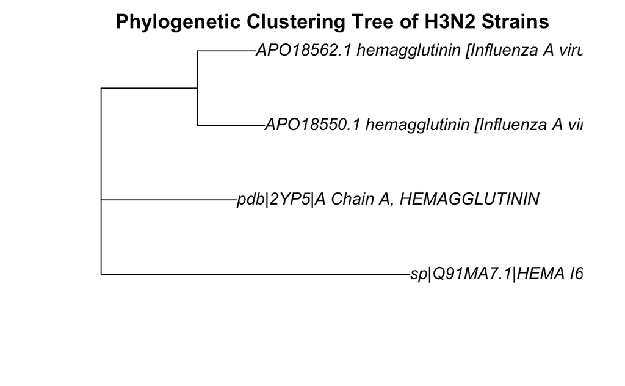

```r
#plot phylogenetic tree
H3N2_tree<-nj(d)
plot.phylo(H3N2_tree, main="Phylogenetic Clustering Tree of H3N2 Strains")
```

```r
#load library
library(bio3d)
library(readr)

#read in pdb files from protein data bank
H3N2_hongkong<-read.pdb("1968.pdb")
H3N2_florida<-read.pdb("2016.pdb")
H3N2_tenessee<-read.pdb("coords.pdb")

#code check by looking at summary of pdb file to make sure matches with the
hongkong_trim<-trim.pdb(H3N2_hongkong, chain="A")
summary(hongkong_trim)
```

```
 Call:  trim.pdb(pdb = H3N2_hongkong, chain = "A")

   Total Models#: 1
     Total Atoms#: 2745,  XYZs#: 8235  Chains#: 1  (values: A)

     Protein Atoms#: 2480  (residues/Calpha atoms#: 321)
     Nucleic acid Atoms#: 0  (residues/phosphate atoms#: 0)

     Non-protein/nucleic Atoms#: 265  (residues: 227)
     Non-protein/nucleic resid values: [ HOH (223), NAG (2), PEG (2) ]

+ attr: atom, helix, sheet, seqres, xyz,
        calpha, call
```

```r
#binding.site was used to visualize the residues around the binding site of the strain H3N2
binding.site(hongkong_trim)
```

```
$inds

 Call:  NULL

   Atom Indices#: 170  ($atom)
   XYZ  Indices#: 510  ($xyz)

+ attr: atom, xyz

$resnames
 [1] "ASN 22 (A)"  "GLY 23 (A)"  "THR 24 (A)"  "THR 37 (A)"  "ASN 38 (A)"
 [6] "ALA 39 (A)"  "GLN 80 (A)"  "ASN 81 (A)"  "ARG 109 (A)" "GLU 119 (A)"
[11] "PHE 120 (A)" "ILE 121 (A)" "ARG 150 (A)" "SER 266 (A)" "ILE 267 (A)"
[16] "MET 268 (A)" "ARG 269 (A)" "PRO 284 (A)" "LYS 299 (A)" "ILE 300 (A)"
[21] "THR 301 (A)"

$resno
 [1]  22  23  24  37  38  39  80  81 109 119 120 121 150 266 267 268 269 284
[19] 299 300 301

$chain
 [1] "A" "A" "A" "A" "A" "A" "A" "A" "A" "A" "A" "A" "A" "A" "A" "A" "A" "A"
[19] "A" "A" "A"

$call
binding.site(a = hongkong_trim)
```

```r
#print first couple atoms of the H3N2 2016 strains from florida and tenessee to compare to the residues found at the binding site of hongkongs resno 24
H3N2_florida$atom[1:2,]
```

|  | type | eleno | elety | alt | resid | chain | resno | insert | x | y | z | o | b | segid | elesy | charge |
| --- | --- | --- | --- | --- | --- | --- | --- | --- | --- | --- | --- | --- | --- | --- | --- | --- |
| 1 | ATOM | 1 | N | NA | ASN | A | 24 | NA | -5.081 | -38.636 | 75.610 | 1 | 0.58 | NA | N | NA |
| 2 | ATOM | 2 | CA | NA | ASN | A | 24 | NA | -4.061 | -37.517 | 75.674 | 1 | 0.58 | NA | C | NA |

```r
H3N2_tenessee$atom[1:2, ]
```

|  | type | eleno | elety | alt | resid | chain | resno | insert | x | y | z | o | b | segid | elesy | charge |
| --- | --- | --- | --- | --- | --- | --- | --- | --- | --- | --- | --- | --- | --- | --- | --- | --- |
| 1 | ATOM | 1 | N | NA | ASN | A | 24 | NA | -5.094 | -38.621 | 75.620 | 1 | 0.6 | NA | N | NA |
| 2 | ATOM | 2 | CA | NA | ASN | A | 24 | NA | -4.068 | -37.513 | 75.682 | 1 | 0.6 | NA | C | NA |

```r
H3N2_tenessee$xyz
```

```
   Total Frames#: 1
   Total XYZs#:   35316,  (Atoms#:  11772)

    [1]  -5.094  -38.621  75.62  <...>  12.061  -53.214  82.453  [35316]

+ attr: Matrix DIM = 1 x 35316
```